# FoodHub Data Analysis

### Context

The number of restaurants in New York is increasing day by day. Lots of students and busy professionals rely on those restaurants due to their hectic lifestyles. Online food delivery service is a great option for them. It provides them with good food from their favorite restaurants. A food aggregator company FoodHub offers access to multiple restaurants through a single smartphone app.

The app allows the restaurants to receive a direct online order from a customer. The app assigns a delivery person from the company to pick up the order after it is confirmed by the restaurant. The delivery person then uses the map to reach the restaurant and waits for the food package. Once the food package is handed over to the delivery person, he/she confirms the pick-up in the app and travels to the customer's location to deliver the food. The delivery person confirms the drop-off in the app after delivering the food package to the customer. The customer can rate the order in the app. The food aggregator earns money by collecting a fixed margin of the delivery order from the restaurants.

### Objective

The food aggregator company has stored the data of the different orders made by the registered customers in their online portal. They want to analyze the data to get a fair idea about the demand of different restaurants which will help them in enhancing their customer experience. Suppose you are hired as a Data Scientist in this company and the Data Science team has shared some of the key questions that need to be answered. Perform the data analysis to find answers to these questions that will help the company to improve the business.

### Data Description

The data contains the different data related to a food order. The detailed data dictionary is given below.

### Data Dictionary

- order_id: Unique ID of the order
- customer_id: ID of the customer who ordered the food
- restaurant_name: Name of the restaurant
- cuisine_type: Cuisine ordered by the customer
- cost: Cost of the order
- day_of_the_week: Indicates whether the order is placed on a weekday or weekend (The weekday is from Monday to Friday and the weekend is Saturday and Sunday)
- rating: Rating given by the customer out of 5
- food_preparation_time: Time (in minutes) taken by the restaurant to prepare the food. This is calculated by taking the difference between the timestamps of the restaurant's order confirmation and the delivery person's pick-up confirmation.
- delivery_time: Time (in minutes) taken by the delivery person to deliver the food package. This is calculated by taking the difference between the timestamps of the delivery person's pick-up confirmation and drop-off information

### Let us start by importing the required libraries

```python
# import libraries for data manipulation
import numpy as np
import pandas as pd

# import libraries for data visualization
import matplotlib.pyplot as plt
import seaborn as sns
```

### Understanding the structure of the data

```python
# uncomment and run the following lines for Google Colab
# from google.colab import drive
# drive.mount('/content/drive')
```

**Please note i'm doing this in jupyter notebook (via Anaconda) so i won't mount it to my drive and read the file from my local storage**

```python
# read the data
df = pd.read_csv(r"D:\ONLINE Learning\MIT Online\Project Assessment 1\foodhub_order.csv")
# returns the first 5 rows
df.head()
```

|  | order_id | customer_id | restaurant_name | cuisine_type | cost_of_the_order | day_of_the_week | rating | food_preparation_time | delivery_time |
| --- | --- | --- | --- | --- | --- | --- | --- | --- | --- |
| 0 | 1477147 | 337525 | Hangawi | Korean | 30.75 | Weekend | Not given | 25 | 20 |
| 1 | 1477685 | 358141 | Blue Ribbon Sushi Izakaya | Japanese | 12.08 | Weekend | Not given | 25 | 23 |
| 2 | 1477070 | 66393 | Cafe Habana | Mexican | 12.23 | Weekday | 5 | 23 | 28 |
| 3 | 1477334 | 106968 | Blue Ribbon Fried Chicken | American | 29.20 | Weekend | 3 | 25 | 15 |
| 4 | 1478249 | 76942 | Dirty Bird to Go | American | 11.59 | Weekday | 4 | 25 | 24 |

#### Observations:

The DataFrame has 9 columns as mentioned in the Data Dictionary. Data in each row corresponds to the order placed by a customer.

### **Question 1:** How many rows and columns are present in the data?

```python
# Write your code here
df.shape
```

```
(1898, 9)
```

#### Observations:

The data has 1898 rows and 9 columns.

### **Question 2:** What are the datatypes of the different columns in the dataset? (The info() function can be used)

```python
# Use info() to print a concise summary of the DataFrame
df.info()
```

```
<class 'pandas.core.frame.DataFrame'>
RangeIndex: 1898 entries, 0 to 1897
Data columns (total 9 columns):
 #   Column                 Non-Null Count  Dtype
---  ------                 --------------  -----
 0   order_id               1898 non-null   int64
 1   customer_id            1898 non-null   int64
 2   restaurant_name        1898 non-null   object
 3   cuisine_type           1898 non-null   object
 4   cost_of_the_order      1898 non-null   float64
 5   day_of_the_week        1898 non-null   object
 6   rating                 1898 non-null   object
 7   food_preparation_time  1898 non-null   int64
 8   delivery_time          1898 non-null   int64
dtypes: float64(1), int64(4), object(4)
memory usage: 133.6+ KB
```

#### Observations:

There are integers, objects and float type data

### **Question 3:** Are there any missing values in the data? If yes, treat them using an appropriate method

```python
# Write your code here
df.isnull().any()
```

```
order_id                 False
customer_id              False
restaurant_name          False
cuisine_type             False
cost_of_the_order        False
day_of_the_week          False
rating                   False
food_preparation_time    False
delivery_time            False
dtype: bool
```

#### Observations:

- No NULL/ missing values in the data

### **Question 4:** Check the statistical summary of the data. What is the minimum, average, and maximum time it takes for food to be prepared once an order is placed?

```python
# Write your code here
df.describe(include='all').T
```

|  | count | unique | top | freq | mean | std | min | 25% | 50% | 75% | max |
| --- | --- | --- | --- | --- | --- | --- | --- | --- | --- | --- | --- |
| order_id | 1898.0 | NaN | NaN | NaN | 1477495.5 | 548.049724 | 1476547.0 | 1477021.25 | 1477495.5 | 1477969.75 | 1478444.0 |
| customer_id | 1898.0 | NaN | NaN | NaN | 171168.478398 | 113698.139743 | 1311.0 | 77787.75 | 128600.0 | 270525.0 | 405334.0 |
| restaurant_name | 1898 | 178 | Shake Shack | 219 | NaN | NaN | NaN | NaN | NaN | NaN | NaN |
| cuisine_type | 1898 | 14 | American | 584 | NaN | NaN | NaN | NaN | NaN | NaN | NaN |
| cost_of_the_order | 1898.0 | NaN | NaN | NaN | 16.498851 | 7.483812 | 4.47 | 12.08 | 14.14 | 22.2975 | 35.41 |
| day_of_the_week | 1898 | 2 | Weekend | 1351 | NaN | NaN | NaN | NaN | NaN | NaN | NaN |
| rating | 1898 | 4 | Not given | 736 | NaN | NaN | NaN | NaN | NaN | NaN | NaN |
| food_preparation_time | 1898.0 | NaN | NaN | NaN | 27.37197 | 4.632481 | 20.0 | 23.0 | 27.0 | 31.0 | 35.0 |
| delivery_time | 1898.0 | NaN | NaN | NaN | 24.161749 | 4.972637 | 15.0 | 20.0 | 25.0 | 28.0 | 33.0 |

### **Question 5:** How many orders are not rated?

```python
# Write the code here
df['rating'].value_counts()
```

```
Not given    736
5            588
4            386
3            188
Name: rating, dtype: int64
```

#### Observations:

- There are 736 out of 1898 orders that were not rated -'Not given' (38.78%)

### Exploratory Data Analysis (EDA)

### **Question 6:** Explore all the variables and provide observations on their distributions. (Generally, histograms, boxplots, countplots, etc. are used for univariate exploration)

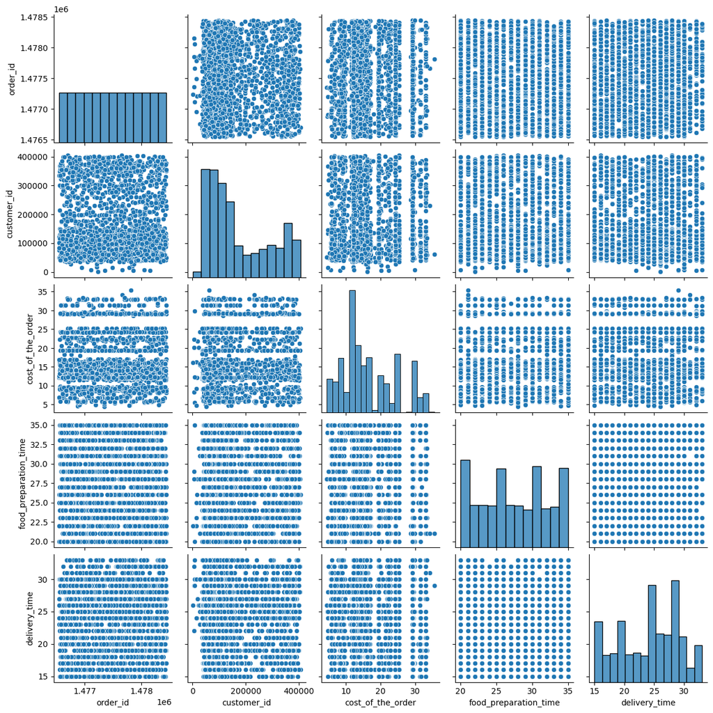

```python
# Write the code here
import matplotlib.pyplot as plt
import seaborn as sns
# Using pairplot to see overall big picture
sns.pairplot(data=df)
```

**Couldn't really derive any substantial insights, let's dive deep onto the available numerical variables**

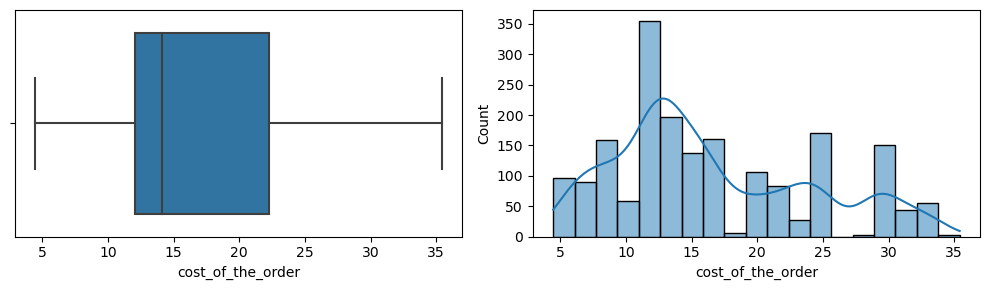

```python
#let's look at cost of order
fig, axs = plt.subplots(nrows=1, ncols=2, figsize=(10, 3))

# Boxplot on the first subplot
sns.boxplot(data=df, x='cost_of_the_order', ax=axs[0])

# Histogram with KDE on the second subplot
sns.histplot(data=df, x='cost_of_the_order', kde=True, ax=axs[1])

# Display the plots
plt.tight_layout()
plt.show()
```

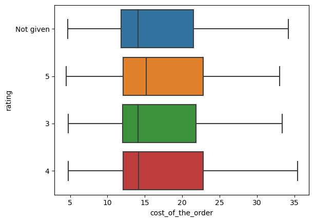

```python
#Looking at cost of order against rating
sns.boxplot(data=df, x='cost_of_the_order',y ='rating');
```

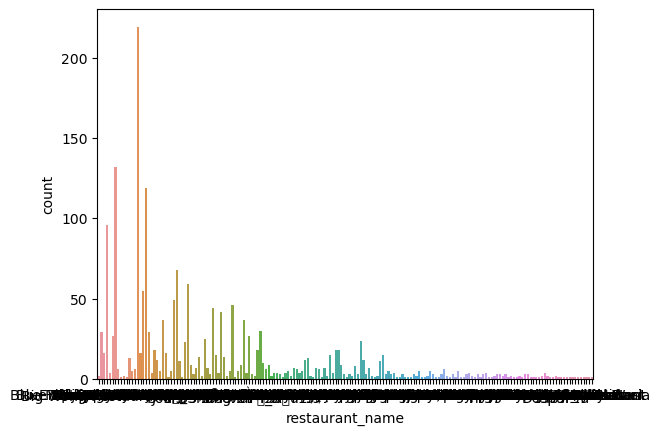

```python
# Looking at the big picture to see if there are any restaurants that received way more orders compared to the rest
sns.countplot(data=df, x='restaurant_name');
```

As we can see, there are some restaurants that received substantially more orders, however, visualisation via countplot might not be the best choice

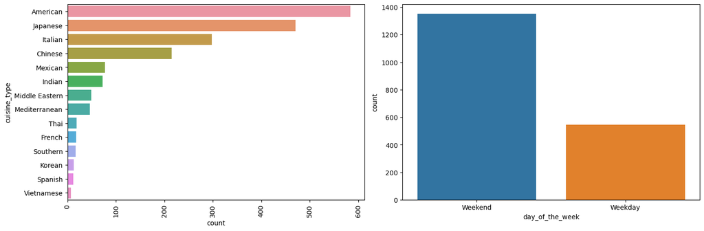

```python
# Looking at the popularity distribution of cuisine type and days of order
fig, axs = plt.subplots(nrows=1, ncols=2, figsize=(15, 5))
sns.countplot(data=df, y='cuisine_type',ax=axs[0],order=df['cuisine_type'].value_counts().index);
axs[0].tick_params(axis='x', rotation=90)
sns.countplot(data=df, x='day_of_the_week',ax=axs[1]);
plt.tight_layout()
plt.show()
```

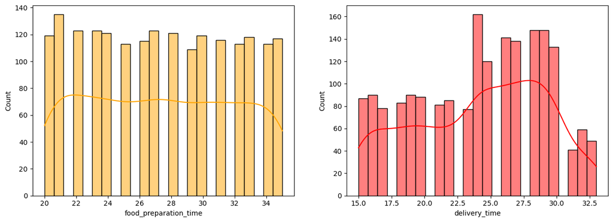

```python
# looking at distribution of food preparation and delivery time
fig, axs=plt.subplots(nrows=1, ncols=2, figsize=(15,5))
sns.histplot(df['food_preparation_time'], kde=True, color='orange',bins=25, ax=axs[0])
sns.histplot(df['delivery_time'], kde=True, color='red', bins=25,ax=axs[1])
plt.show()
```

### **Question 7**: Which are the top 5 restaurants in terms of the number of orders received?

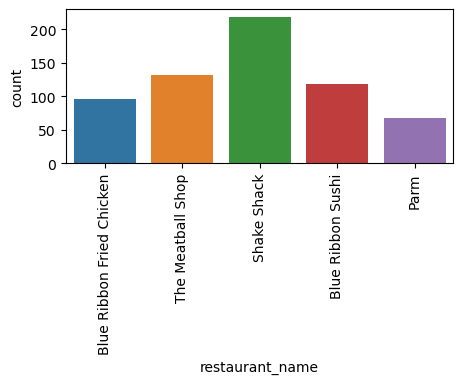

```python
# Write the code here
# Get the count results in descending order
top_5_restaurants = df['restaurant_name'].value_counts().head(5).index
top_5_restaurants_df=df[df['restaurant_name'].isin(top_5_restaurants)]
#top_5_restaurants_df.restaurant_name.nunique()
plt.figure(figsize=(5,2))
sns.countplot(data=top_5_restaurants_df, x='restaurant_name')
plt.xticks(rotation=90)
plt.show()
```

```python
top_5_restaurants_df['restaurant_name'].value_counts()
```

```
Shake Shack                  219
The Meatball Shop            132
Blue Ribbon Sushi            119
Blue Ribbon Fried Chicken     96
Parm                          68
Name: restaurant_name, dtype: int64
```

#### Observations:

- We can see shake Shack was the leader (Top 1) followed by The Meatball Shop, Blue Ribbon Sushi, Blue Ribbon Fried Chicken, and Parm

### **Question 8**: Which is the most popular cuisine on weekends?

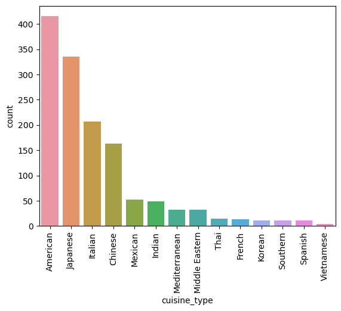

```python
# Write the code here
# Get most popular cuisine on weekends
weekend_df = df[df['day_of_the_week'].isin(['Weekend'])]
sns.countplot(data=weekend_df, x='cuisine_type',order=weekend_df['cuisine_type'].value_counts().index)
plt.xticks(rotation=90)
plt.show()
```

```python
weekend_df['cuisine_type'].value_counts()
```

```
American          415
Japanese          335
Italian           207
Chinese           163
Mexican            53
Indian             49
Mediterranean      32
Middle Eastern     32
Thai               15
French             13
Korean             11
Southern           11
Spanish            11
Vietnamese          4
Name: cuisine_type, dtype: int64
```

#### Observations:

We can see that American cuisine followed by Japanese, and Italian are the most popular cuisine ordered on weekends

### **Question 9**: What percentage of the orders cost more than 20 dollars?

```python
# Write the code here
# Getting df where all cost of order is more than $20
df_Q9 = df[df['cost_of_the_order'] > 20]
#dividing it's row number with the original df row number
percentage = df_Q9.shape[0] / df.shape[0] * 100
print('Percentage of the orders costing more than $20 dollars= {:.2f}%'.format(percentage))
```

```
Percentage of the orders costing more than $20 dollars= 29.24%
```

#### Observations:

Percentage of the orders costing more than $20 dollars= 29.24%

### **Question 10**: What is the mean order delivery time?

```python
# Write the code here
mean=df['delivery_time'].mean()
print('Mean order delivery time= {:.2f} minutes'.format(mean))
```

```
Mean order delivery time= 24.16 minutes
```

#### Observations:

Mean order delivery time= 24.16 minutes

### **Question 11:** The company has decided to give 20% discount vouchers to the top 3 most frequent customers. Find the IDs of these customers and the number of orders they placed

```python
# Write the code here
# Get the counts of  each customer_id
Top3Cust=df['customer_id'].value_counts().head(3)
Top3Cust
```

```
52832    13
47440    10
83287     9
Name: customer_id, dtype: int64
```

#### Observations:

Customer ID: 52832, 47440, and 83287 were the TOP 3 most frequent customers and each made 13, 10, and 9 orders respectively

### **Question 12**: Perform a multivariate analysis to explore relationships between the important variables in the dataset. (It is a good idea to explore relations between numerical variables as well as relations between numerical and categorical variables)

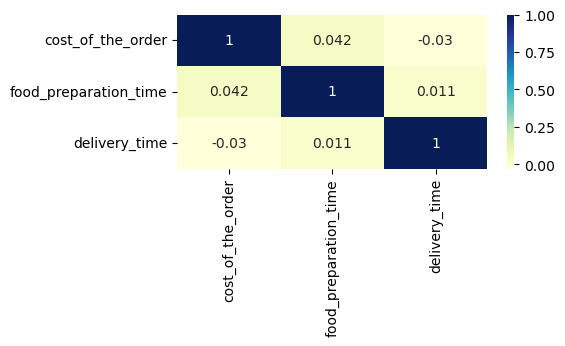

```python
# Write the code here
# Exploring relations between numerical variables
plt.figure(figsize=(5,2))
sns.heatmap(data=df[['cost_of_the_order', 'food_preparation_time', 'delivery_time']].corr(),
            annot=True, cmap='YlGnBu');#yellowGreenBlue
```

*Looks like there's no strong correlation between these numerical variables*

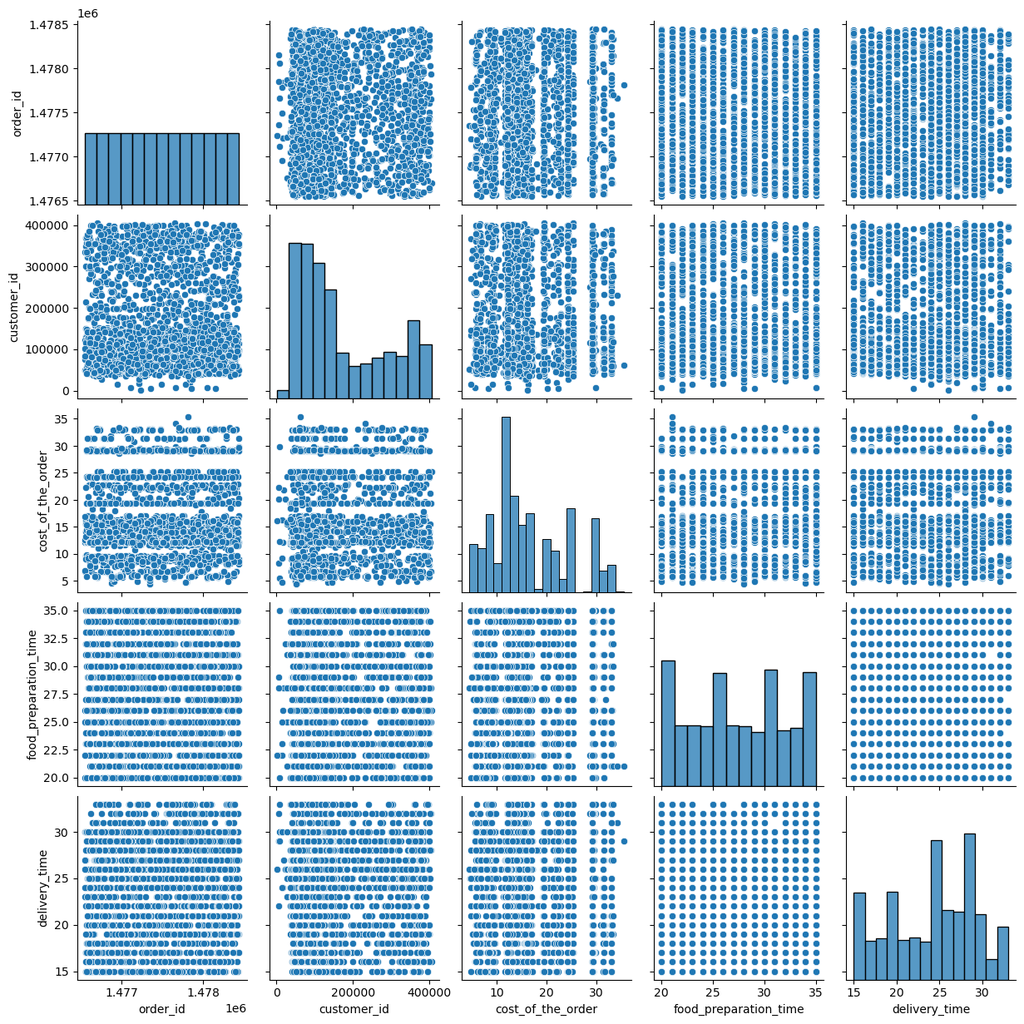

```python
sns.pairplot(data=df)
```

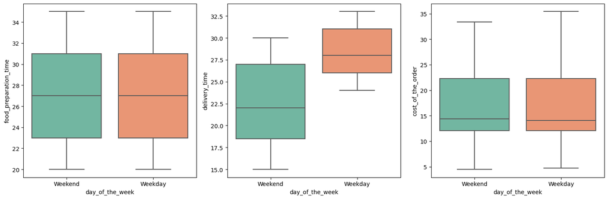

```python
#Days of the week vs 1. Food prep time, 2. Delivery time, and 3. Order cost
fig, axs = plt.subplots(nrows=1, ncols=3, figsize=(15, 5))
sns.boxplot(data=df, x='day_of_the_week', y='food_preparation_time', ax=axs[0],palette='Set2')
sns.boxplot(data=df, x='day_of_the_week', y='delivery_time', ax=axs[1],palette='Set2')
sns.boxplot(data=df, x='day_of_the_week', y='cost_of_the_order', ax=axs[2],palette='Set2')
plt.tight_layout()
plt.show()
```

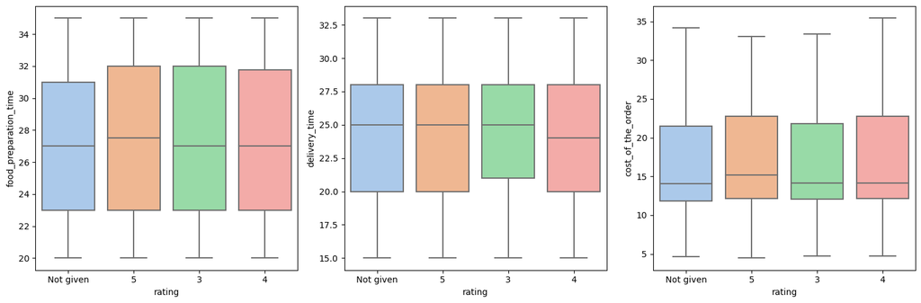

```python
#Rating vs 1. Food prep time, 2. Delivery time, 3. Order cost
fig, axs = plt.subplots(nrows=1, ncols=3, figsize=(15, 5))
sns.boxplot(data=df, x='rating', y='food_preparation_time', ax=axs[0],palette='pastel')
sns.boxplot(data=df, x='rating', y='delivery_time', ax=axs[1],palette='pastel')
sns.boxplot(data=df, x='rating', y='cost_of_the_order', ax=axs[2],palette='pastel')
plt.tight_layout()
plt.show()
```

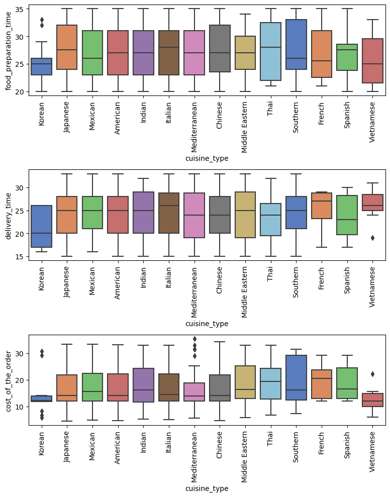

```python
# Comparing Cuisine type vs 1. Food prep time, 2. Delivery time, 3. Order cost
fig, axs = plt.subplots(nrows=3, ncols=1, figsize=(8, 10))
sns.boxplot(data=df, x='cuisine_type', y='food_preparation_time', ax=axs[0],palette='muted')
sns.boxplot(data=df, x='cuisine_type', y='delivery_time', ax=axs[1],palette='muted')
sns.boxplot(data=df, x='cuisine_type', y='cost_of_the_order', ax=axs[2],palette='muted')

# Rotating x-ticks for each subplot
for ax in axs:
    ax.set_xticklabels(ax.get_xticklabels(), rotation=90)
plt.tight_layout()
plt.show()
```

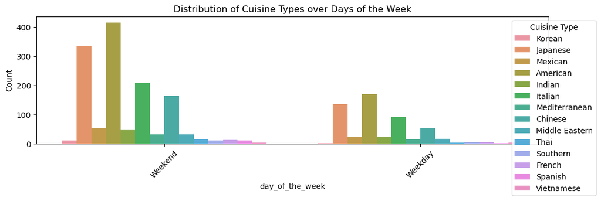

```python
# Now for categorical variables days of the week vs cuisine type
# Creating a count plot
plt.figure(figsize=(12, 3))
sns.countplot(x='day_of_the_week', hue='cuisine_type', data=df)

plt.title("Distribution of Cuisine Types over Days of the Week")
plt.ylabel("Count")
plt.legend(title='Cuisine Type', loc='upper right',bbox_to_anchor=(1.1, 1))
plt.xticks(rotation=45)
plt.show()
```

```
rating                                 3         4         5  Not given
day_of_the_week cuisine_type
Weekday         American        0.124260  0.242604  0.289941   0.343195
                Chinese         0.115385  0.153846  0.230769   0.500000
                French          0.000000  0.200000  0.200000   0.600000
                Indian          0.125000  0.083333  0.375000   0.416667
                Italian         0.098901  0.208791  0.373626   0.318681
                Japanese        0.096296  0.155556  0.296296   0.451852
                Korean          0.000000  0.500000  0.500000   0.000000
                Mediterranean   0.285714  0.214286  0.285714   0.214286
                Mexican         0.125000  0.166667  0.375000   0.333333
                Middle Eastern  0.058824  0.352941  0.470588   0.117647
                Southern        0.166667  0.333333  0.166667   0.333333
                Spanish         0.000000  0.000000  0.000000   1.000000
                Thai            0.000000  0.250000  0.000000   0.750000
                Vietnamese      0.666667  0.000000  0.000000   0.333333
Weekend         American        0.103614  0.214458  0.301205   0.380723
                Chinese         0.110429  0.196319  0.349693   0.343558
                French          0.153846  0.153846  0.307692   0.384615
                Indian          0.040816  0.224490  0.469388   0.265306
                Italian         0.091787  0.169082  0.270531   0.468599
                Japanese        0.080597  0.208955  0.304478   0.405970
                Korean          0.181818  0.272727  0.181818   0.363636
                Mediterranean   0.156250  0.125000  0.375000   0.343750
                Mexican         0.056604  0.226415  0.320755   0.396226
                Middle Eastern  0.125000  0.312500  0.156250   0.406250
                Southern        0.000000  0.454545  0.363636   0.181818
                Spanish         0.000000  0.090909  0.454545   0.454545
                Thai            0.000000  0.133333  0.400000   0.466667
                Vietnamese      0.000000  0.250000  0.500000   0.250000
```

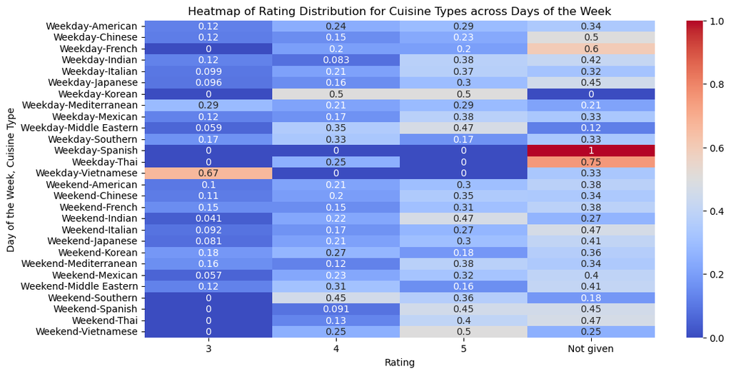

```python
# Let's incorporate rating here, we'll create a new crosstab table with index = days of the week and cuisine type and column
# rating as values
# We'll asign rating for column and then look at their heatmap
contingency_table = pd.crosstab(index=[df['day_of_the_week'], df['cuisine_type']], columns=df['rating'], normalize='index')
print(contingency_table)
# Plotting the heatmap
plt.figure(figsize=(12, 6))
sns.heatmap(contingency_table, annot=True, cmap='coolwarm')

plt.title("Heatmap of Rating Distribution for Cuisine Types across Days of the Week")
plt.ylabel("Day of the Week, Cuisine Type")
plt.xlabel("Rating")
plt.show()
```

#### Observations:

1. Pairplot & heatmap - Numerical Variables:

No visible linear relationship between the numerical variables (cost_of_the_order, food_preparation_time, and delivery_time).

2. Relationships between Categorical and Numerical Variables:
- Day of the Week and Numerical Variables:

The day of the week doesn't seem to have a significant impact on the cost of the order AND food preparation time.**HOWEVER**, there seems to be an impact made on weekday delivery time. This is worth to dive deeper at since most orders came on weekends

- Rating and Numerical Variables:

The distributions of the 3 numerical variables appear relatively uniform across different ratings, suggesting no significant variation of these numerical variables with respect to the ratings

- Cuisine Type and Numerical Variables:  
  *vs Cost*. There are notable differences in the median costs and the overall distribution of order costs among different cuisine types. This suggests that the cost is influenced by the type of cuisine, with some cuisines typically having higher or lower costs.  
  *vs Preparation time* . Some cuisines show a broader range of preparation times than others, indicated by the size of the boxes and the spread of the whiskers and outliers.  
  *vs Delivery Time*. There are variations to small extent, although the variations might not be as pronounced as with the cost and preparation time. Nonetheless, this indicates that certain cuisines might generally require more or less time for delivery
3. Heatmap - Categorical variables (day of the week, rating, and cuisine_type)

Deeper dive on this is optional, but i can see that there were some insights that might be a point of consideration such as: all customer who eats spanish cuisine on weekdays historically didnt leave any rating, some days might consistently show higher or lower ratings across all or most cuisine types.

### **Question 13:** The company wants to provide a promotional offer in the advertisement of the restaurants. The condition to get the offer is that the restaurants must have a rating count of more than 50 and the average rating should be greater than 4. Find the restaurants fulfilling the criteria to get the promotional offer

```python
# checking df rating values, grouping by restaurant name
df.groupby('restaurant_name')['rating'].value_counts()
```

```
restaurant_name   rating
'wichcraft        5            1
12 Chairs         Not given    2
                  4            1
                  5            1
5 Napkin Burger   Not given    3
                              ..
ilili Restaurant  5            4
                  3            2
indikitch         Not given    2
                  4            1
                  5            1
Name: rating, Length: 415, dtype: int64
```

```python
# create a copy of original df since we'll manipulate this df2 (replacing rating='Not given' into NaN)
df2=df.copy()
df2.replace('Not given', np.nan,inplace=True)
df2.groupby('restaurant_name')['rating'].value_counts()
```

```
restaurant_name   rating
'wichcraft        5         1
12 Chairs         4         1
                  5         1
5 Napkin Burger   3         1
                  5         1
                           ..
ilili Restaurant  4         7
                  5         4
                  3         2
indikitch         4         1
                  5         1
Name: rating, Length: 281, dtype: int64
```

```python
# create dataframe
df2=pd.DataFrame(df2)
#now since previously rating column was an object (due to string 'NOT GIVEN'),let's convert it into numeric
df2['rating']=pd.to_numeric(df2['rating'], errors='coerce')
#now we can use aggregation on the rating column
restaurant_ratings = df2.groupby('restaurant_name').agg(rating_count=('rating', 'count'),avg_rating=('rating', 'mean')
                                                        )
print(restaurant_ratings)
```

```
                  rating_count  avg_rating
restaurant_name
'wichcraft                   1    5.000000
12 Chairs                    2    4.500000
5 Napkin Burger              2    4.000000
67 Burger                    1    5.000000
Alidoro                      0         NaN
...                        ...         ...
Zero Otto Nove               1    4.000000
brgr                         1    3.000000
da Umberto                   1    5.000000
ilili Restaurant            13    4.153846
indikitch                    2    4.500000

[178 rows x 2 columns]
```

```python
#filtering restaurants that have a rating count of more than 50 and the average rating should be greater than 4
filtered_restaurants = restaurant_ratings[
    (restaurant_ratings['rating_count'] > 50) & (restaurant_ratings['avg_rating'] > 4)
]
print(filtered_restaurants)
```

```
                           rating_count  avg_rating
restaurant_name
Blue Ribbon Fried Chicken            64    4.328125
Blue Ribbon Sushi                    73    4.219178
Shake Shack                         133    4.278195
The Meatball Shop                    84    4.511905
```

#### Observations:

There are 4 restaurants that fulfil the given criteria, they are:

1. Blue Ribbon Fried Chicken
2. Blue Ribbon Sushi
3. Shake Shack, and
4. The Meatball Shop

### **Question 14:** The company charges the restaurant 25% on the orders having cost greater than 20 dollars and 15% on the orders having cost greater than 5 dollars. Find the net revenue generated by the company across all orders

```python
# Write the code here
# i'll create a Function to calculate revenue based on cost_of_the_order
def calculate_revenue(cost):
    if cost > 20:
        return cost * 0.25
    elif cost > 5:
        return cost * 0.15
    else:
        return 0

# Apply the function to the cost_of_the_order column and sum up the revenues (create new column)
df['revenue'] = df['cost_of_the_order'].apply(calculate_revenue)
total_revenue = df['revenue'].sum()

total_revenue
```

```
6166.303
```

```python
# see the additional "revenue" column in df
df
```

|  | order_id | customer_id | restaurant_name | cuisine_type | cost_of_the_order | day_of_the_week | rating | food_preparation_time | delivery_time | revenue |
| --- | --- | --- | --- | --- | --- | --- | --- | --- | --- | --- |
| 0 | 1477147 | 337525 | Hangawi | Korean | 30.75 | Weekend | Not given | 25 | 20 | 7.6875 |
| 1 | 1477685 | 358141 | Blue Ribbon Sushi Izakaya | Japanese | 12.08 | Weekend | Not given | 25 | 23 | 1.8120 |
| 2 | 1477070 | 66393 | Cafe Habana | Mexican | 12.23 | Weekday | 5 | 23 | 28 | 1.8345 |
| 3 | 1477334 | 106968 | Blue Ribbon Fried Chicken | American | 29.20 | Weekend | 3 | 25 | 15 | 7.3000 |
| 4 | 1478249 | 76942 | Dirty Bird to Go | American | 11.59 | Weekday | 4 | 25 | 24 | 1.7385 |
| ... | ... | ... | ... | ... | ... | ... | ... | ... | ... | ... |
| 1893 | 1476701 | 292602 | Chipotle Mexican Grill $1.99 Delivery | Mexican | 22.31 | Weekend | 5 | 31 | 17 | 5.5775 |
| 1894 | 1477421 | 397537 | The Smile | American | 12.18 | Weekend | 5 | 31 | 19 | 1.8270 |
| 1895 | 1477819 | 35309 | Blue Ribbon Sushi | Japanese | 25.22 | Weekday | Not given | 31 | 24 | 6.3050 |
| 1896 | 1477513 | 64151 | Jack's Wife Freda | Mediterranean | 12.18 | Weekday | 5 | 23 | 31 | 1.8270 |
| 1897 | 1478056 | 120353 | Blue Ribbon Sushi | Japanese | 19.45 | Weekend | Not given | 28 | 24 | 2.9175 |

1898 rows × 10 columns

#### Observations:

- **The total revenue generated by the company across all order is $6,166.303**

### **Question 15:** The company wants to analyze the total time required to deliver the food. What percentage of orders take more than 60 minutes to get delivered from the time the order is placed? (The food has to be prepared and then delivered)

```python
# Write the code here
# Calculate total time from order to delivery (creating new column)
df['total_time'] = df['food_preparation_time'] + df['delivery_time']

# Determine the percentage of orders that take more than 60 minutes
orders_over_60_minutes = (df['total_time'] > 60).sum()
ori_total_orders = df.shape[0]
percentage_over_60_minutes = (orders_over_60_minutes / ori_total_orders) * 100

# printing values
orders_over_60_minutes, ori_total_orders, percentage_over_60_minutes
```

```
(200, 1898, 10.537407797681771)
```

#### Observations:

- out of 1898 total orders, 200 take more than 60 minutes from placement to delivery. This represents around 10.54% of the orders

### **Question 16:** The company wants to analyze the delivery time of the orders on weekdays and weekends. How does the mean delivery time vary during weekdays and weekends?

```python
# Write the code here
mean_delivery_times = df.groupby('day_of_the_week')['delivery_time'].mean()
mean_delivery_times
```

```
day_of_the_week
Weekday    28.340037
Weekend    22.470022
Name: delivery_time, dtype: float64
```

#### Observations:

As you can see above and from Q12 days of the week vs delivery time boxplot, mean delivery time for orders is around:

- 28.34 mins on weekdays and 22.47 mins on weekends.

This indicates that delivery times are generally shorter during the weekend compared to weekdays.

### Conclusion and Recommendations

### **Question 17:** What are your conclusions from the analysis? What recommendations would you like to share to help improve the business? (You can use cuisine type and feedback ratings to drive your business recommendations)

### Conclusions:

- Lack of Linear Relationship: Linear relationships among numerical variables (cost, preparation time, and delivery time) suggests that these variables influence each other in non-linear ways or are influenced more by external factors like cuisine type or operational efficiency.
- Customer Rating Insights: Distribution of numerical variables across ratings implies that factors like cost, preparation, and delivery time might NOT directly influence how customers rate their experience. Other qualitative factors like food quality, customer service, and overall satisfaction may be worth to explore.
- Revenue: The company generates substantial revenue from commissions (business model), particularly from higher-cost orders.
- Delivery Times: Weekends deliveries are faster than on weekdays. Additionally, around 10.54% of total orders take longer than 60 mins, which could be room for improvement.
- Order volume by days:Weekends see higher order volumes than weekdays, suggesting that users are more likely to order out on weekend
- Cuisine Preferences: American, Japanese, Italian, and Chinese cuisines dominate in popularity, pointing towards a diverse customer base. with varied tastes. Preferences for American and Japanese cuisines are more during weekends.
- Restaurant Popularity: Certain restaurants like Shake Shack, The Meatball Shop, and Blue Ribbon Sushi lead in order volumes, indicating strong brand preferences or better customer experiences at these places.

### Recommendations:

1. Focus on Higher Value Orders, Leverage Popular Restaurants
- Given the revenue model, promoting high-value orders can significantly increase earnings. We can create incentives for customers to place larger orders, such as bundled deals or special discounts on combos.
- Considering that 29.24% of orders are over $20, targeting these higher-value orders with specific promotions or loyalty benefits could boost revenue

Collaborate more closely with restaurants that consistently receive large orders to ensure their needs are med efficiently